# Peer Assessment 1

Miguel M Fonseca

17 Apr 2015

In this file you will find my report for the *Peer Assessment 1* of the [Reproducible Research](https://www.coursera.org/course/repdata) course offered by [Coursera](https://www.coursera.org/)

### Loading and preprocessing the data

In this section, I wrote the r code needed to load and preprocess the data to be used in this assignment.

```r
setwd("/Users/mmfonseca/Documents/work/cursos/2015_Reproducible_Research/Peer_Assessment_1")

## loading the data
ActivityData <- read.csv("activity.csv")
```

```r
library(xtable)
xt <- xtable(head(ActivityData))
print(xt, type = "html")
```

|  | steps | date | interval |
| --- | --- | --- | --- |
| 1 |  | 2012-10-01 | 0 |
| 2 |  | 2012-10-01 | 5 |
| 3 |  | 2012-10-01 | 10 |
| 4 |  | 2012-10-01 | 15 |
| 5 |  | 2012-10-01 | 20 |
| 6 |  | 2012-10-01 | 25 |

### What is mean total number of steps taken per day?

*1. Calculate the total number of steps taken per day*

```r
## In the following command, the number of steps taken per day will be summed up
StepsPerDay <- aggregate(steps ~ date, data = ActivityData, sum)

## just to show how the table looks like
xt <- xtable(head(StepsPerDay))
print(xt, type = "html")
```

|  | date | steps |
| --- | --- | --- |
| 1 | 2012-10-02 | 126 |
| 2 | 2012-10-03 | 11352 |
| 3 | 2012-10-04 | 12116 |
| 4 | 2012-10-05 | 13294 |
| 5 | 2012-10-06 | 15420 |
| 6 | 2012-10-07 | 11015 |

*2. Make a histogram of the total number of steps taken each day*

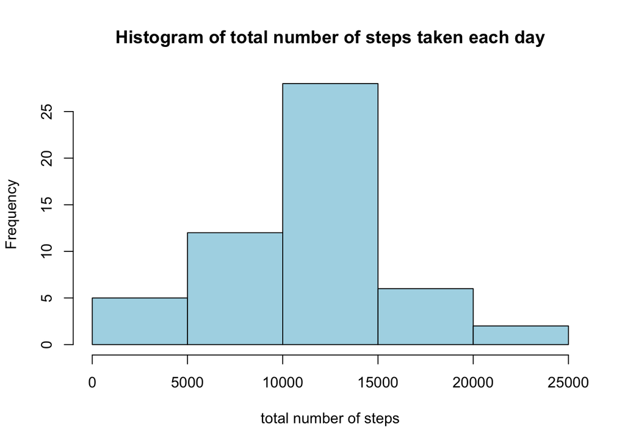

```r
## Draw the histogram
hist(StepsPerDay$steps, xlab="total number of steps",
     main="Histogram of total number of steps taken each day",
     col="lightblue")
```

*3. Calculate and report the mean and median of the total number of steps taken per day*

```r
## For this step, we can use the dataframe created previously (StepsPerDay)
## Note that missing data will be ignored
Mean_StepsPerDay <- mean(StepsPerDay$steps)

## Printing the mean value
show(Mean_StepsPerDay)
```

[1] 10766.19

```r
## Likewise, we can use the function "media()" to calculate the median of the total number
## of steps taken per day
## Note that missing data will be ignored
Median_StepsPerDay <- median(StepsPerDay$steps)

## Printing the median value
show(Median_StepsPerDay)
```

[1] 10765

> The mean of the total number of steps taken per day is **10766.19** and the median of the dataset is **10765**.

### What is the average daily activity pattern?

*1. Make a time series plot of the 5-minute interval (x-axis) and the average number of steps taken, averaged across all days (y-axis)*

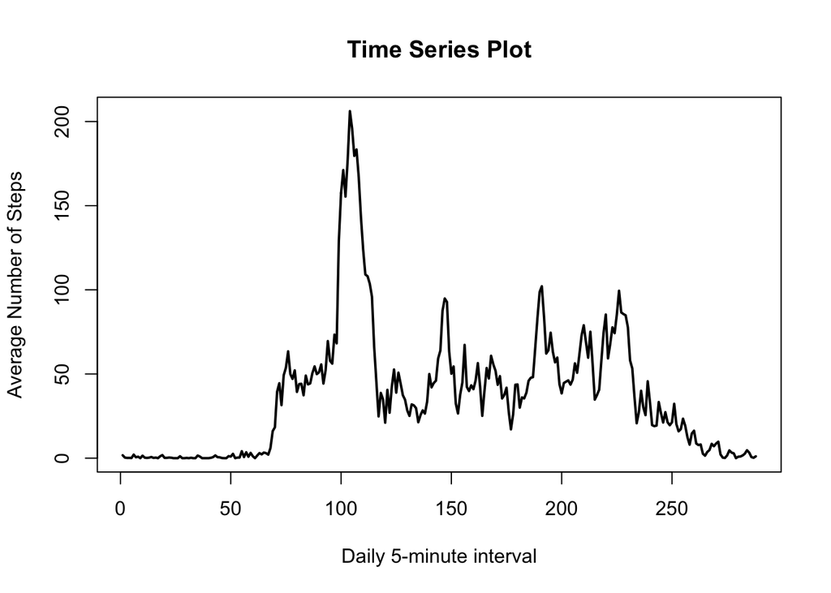

```r
AverageStepsPerInterval <- aggregate(steps ~ interval, data = ActivityData, mean)
plot(AverageStepsPerInterval$steps, type="l", lwd=2,
     ylab="Average Number of Steps",
     xlab="Daily 5-minute interval",
     main="Time Series Plot"
     )
```

*2. Which 5-minute interval, on average across all the days in the dataset, contains the maximum number of steps?*

```r
## To get the max value of a given vector or column, one can use the function which.max
## this function will not report the max value per se,
## instead it will report the index of the 5-minute interval that, on average, contains the maximum number of steps:
which.max(AverageStepsPerInterval$steps)
```

[1] 104

So, the above mentioned index interval (or row number), must corresponde to a specific interval. To get the name of the 5-minute interval, one can use the following:

```r
AverageStepsPerInterval$interval[which.max(AverageStepsPerInterval$steps)]
```

[1] 835

> The 5-minute interval that contains the maximum number of steps (on average across all the days in the dataset is the one named **835**.

### Imputing missing values

*1. Calculate and report the total number of missing values in the dataset (i.e. the total number of rows with NAs)*

```r
nrow(ActivityData[ActivityData$steps == "NA",])
```

[1] 2304

*2. Devise a strategy for filling in all of the missing values in the dataset. The strategy does not need to be sophisticated. For example, you could use the mean/median for that day, or the mean for that 5-minute interval, etc.* I will use the overall 5-minute interval mean to fill the missing values. To do this I will use the values from the dataframe “AverageStepsPerInterval”. Thus, if in the original dataset the value of number of steps is missing, I will substitute it will the average number of steps for that 5-minute interval:

```r
ActivityData2 <- ActivityData

for (i in 1:nrow(ActivityData)){
    interval <- ActivityData$interval[i]
    nsteps <- ActivityData$steps[i]
    newvalue <- AverageStepsPerInterval[AverageStepsPerInterval$interval == interval,2]
    if (is.na(nsteps)){
        ActivityData2$steps[i] <- newvalue
    }
}
```